# Lab: dplyr

36-600

Fall 2022

## Data

We’ll begin by importing some astronomical data from the 36-290 GitHub site. These data are stored in .Rdata format; such data are saved via `R`’s `save()` function and loaded via `R`’s `load()` function. One wrinkle here: the data are stored on the web, so we also have to apply the `url()` function.

```r
file.path = "https://raw.githubusercontent.com/pefreeman/36-290/master/EXAMPLE_DATASETS/BUZZARD/Buzzard_DC1.Rdata"
load(url(file.path))
rm(file.path)
set.seed(101)
s = sample(nrow(df),4000)
predictors = df[s,-c(7:14)]
response   = as.vector(df[s,14])
rm(df,s)
objects() # Shows the loaded variables. (Redundant with the Environment pane.)
```

```
## [1] "predictors" "response"
```

If everything loaded correctly, you should see two variables in your global environment: `predictors` and `response`. `predictors` is a data frame with 4000 rows and 6 columns, and `response` is a vector of length 4000, and it represents *redshift*, which you can think of as a directly observable proxy for the distance of a galaxy from the Earth. (After all, tape measures aren’t going to help us here.)

# Questions

## Question 1

Apply the `dim()`, `nrow()`, `ncol()`, and `length()` functions to `predictors`, so as to build intuition about what these functions output. (Note: we are not using `dplyr` yet, just base `R` functions here.) Do you know why `length()` returns the value it does? Ask me or the TA if you do not. (But fill in an answer below regardless to reinforce the answer.)

```r
# Answer to question 1
dim(predictors)
```

```
## [1] 4000    6
```

```r
nrow(predictors)
```

```
## [1] 4000
```

```r
ncol(predictors)
```

```
## [1] 6
```

```r
length(predictors)
```

```
## [1] 6
```

```
FILL ME IN WITH WORDS FOR QUESTION 1
Length returns a value of 6 because there are 6 columns (or variables) in the predictors data frame
```

## Question 2

Display the names of each column of `predictors`.

```r
# Answer to question 2
names(predictors)
```

```
## [1] "u" "g" "r" "i" "z" "y"
```

```r
#The names of the columns are "u", "g", "r", "i", "z", "y"
```

Time for a digression.

A *magnitude* is a logarithmic measure of brightness that is calibrated such as to be approximately zero for the brightest stars in the night sky (Sirius, Vega, etc.). Every five-unit *increase* in magnitude is a factor of 100 *decrease* in brightness. So a magnitude of 20 means the object is 100 million times fainter than a star like Vega.

Magnitudes are generally measured in particular bands. Imagine that you put a filter in front of a telescope that only lets photons of certain wavelengths pass through. You can then assess the brightness of an object at just those wavelengths. So `u` represents a magnitude determined at ultraviolet wavelengths, with `g`, `r`, and `i` representing green, red, and infrared. (The `z` and `y` are a bit further into the infrared. The names don’t represent words.)

So the predictor data consists of six magnitudes spanning from the near-UV to the near-IR.

## Question 3

Use the base `R` `summary()` function to get a textual summary of the predictors. Do you notice anything strange? (Some values you might not expect?)

```r
# Answer to question 3:
summary(predictors)
```

```
##        u               g               r               i
##  Min.   :19.55   Min.   :18.51   Min.   :18.00   Min.   :17.74
##  1st Qu.:26.37   1st Qu.:25.86   1st Qu.:25.10   1st Qu.:24.55
##  Median :27.34   Median :26.94   Median :26.29   Median :25.74
##  Mean   :33.06   Mean   :26.87   Mean   :25.88   Mean   :25.27
##  3rd Qu.:28.51   3rd Qu.:27.74   3rd Qu.:27.00   3rd Qu.:26.47
##  Max.   :99.00   Max.   :99.00   Max.   :29.41   Max.   :27.00
##        z               y
##  Min.   :17.56   Min.   :17.34
##  1st Qu.:24.21   1st Qu.:23.86
##  Median :25.35   Median :25.04
##  Mean   :24.98   Mean   :25.85
##  3rd Qu.:26.12   3rd Qu.:25.89
##  Max.   :99.00   Max.   :99.00
```

```
FILL ME IN WITH WORDS FOR QUESTION 3:
I am no astronomer, but I find the outliers fairly strange: perhaps that is the data collector's way of showing non-detects since the higher the number, the dimmer the star? I just find it odd that the max value would be consistent over the spectrum otherwise with environmental data.
```

## dplyr

[output not shown]

```r
head(predictors[,1:2])                         # base R
```

```
##              u       g
## 2873   23.5907 21.6827
## 108639 27.1252 26.2652
## 19665  27.4013 26.7235
## 87391  27.9354 27.0586
## 35772  27.7733 27.4076
## 46326  27.1742 26.9353
```

```r
predictors %>% select(.,u,g) %>% head(.)       # dplyr
```

```
##              u       g
## 2873   23.5907 21.6827
## 108639 27.1252 26.2652
## 19665  27.4013 26.7235
## 87391  27.9354 27.0586
## 35772  27.7733 27.4076
## 46326  27.1742 26.9353
```

Let’s do a few exercises here. Be sure to tap into, e.g., StackOverflow and *R for Data Science* for any help you may need.

## Question 4

Grab all data for which `i` is less than 25 and `g` is greater than 22, and output in order of increasing `y`. (Remember: you combine conditions with & for “and” and | for “or”.) Show only the first six lines of output. Note that `head()` by default shows the first six rows of the input data frame.

```r
# Answer for question 4
#Hi Anni, tidyverse will not load onto my R and I am literally losing my mind. Fingers crossed I can complete this assignment with just dplyr!

q4 <-predictors %>% filter(., predictors$i<25 & predictors$g>22) %>% arrange(., y) %>% head
q4
```

```
##         u       g       r       i       z       y
## 1 24.1858 22.0232 20.3907 19.5766 19.1923 18.9443
## 2 24.3510 22.1041 20.4449 19.6847 19.2919 19.0380
## 3 24.4236 22.5979 21.0056 19.8446 19.4433 19.0918
## 4 24.8989 22.8297 21.2118 20.0455 19.6235 19.2732
## 5 23.7571 22.1921 20.6919 19.9896 19.6521 19.3608
## 6 24.1374 22.1437 20.5673 19.9751 19.6583 19.4766
```

## Question 5

To get a quick, textual idea of how the data are distributed: select the `g` column, pipe it to the `round()` function, then pipe the output of `round()` to `table()`. You should notice something strange about the output…the same thing you should have noticed when answering Question 3.

```r
# Answer to question 5

predictors %>% select(., g) %>% round(.) %>% table(.)
```

```
## .
##   19   20   21   22   23   24   25   26   27   28   29   30   31   32   34   99
##    5    5   27   46   99  206  388  722 1224  946  247   51   13    9    1   11
```

```r
#the 99 is present here as well
```

Time for another digression. Domain scientists are not bound by the `R` convention of using `NA` when data are “not available,” or missing. Sometimes the domain scientists will tell you what they use in place of `NA`, sometimes not. In those latter cases, one can usual infer the values. Astronomers for some reason love using -99, -9, 99, etc., to represent missing values. The values of 99 in the table you generated in Question 5 actually represent missing data.

We could change the values of 99 to `NA`, but here we will just filter those rows with values of 99 out of the data frame.

## Question 6

Use `filter()` to determine how many rows contain 99’s. Since 99’s can appear in different columns, you will need to combine conditions together with logical “and”s or “or”s. Note: only four of the six columns have 99’s in them.

```r
# Answer to question 6:
predictors %>% filter(., predictors$u==99 | predictors$g==99 | predictors$r==99 | predictors$i==99 | predictors$z==99 | predictors$y==99) %>% nrow(.)
```

```
## [1] 393
```

```r
#393 rows contain NA's
```

## Question 7

Now repeat Question 6 (in a sense), and remove all the rows that contain 99’s, saving the new data frame as `pred.new`. Hint that may help: the opposite of, e.g., `u==99 | g==99` is `u!=99 & g!=99`.

```r
# Answer to question 7
predictors %>% filter(., predictors$u!=99 & predictors$g!=99 & predictors$r!=99 & predictors$i!=99 & predictors$z!=99 & predictors$y!=99) -> pred.new

pred.new
```

```
##            u       g       r       i       z       y
## 1    23.5907 21.6827 20.0759 19.4611 19.0885 18.8831
## 2    27.1252 26.2652 25.5893 25.0175 24.6461 24.0259
## 3    27.4013 26.7235 26.6074 26.5520 25.7460 25.4095
## 4    27.9354 27.0586 26.3402 25.6980 25.0166 24.2701
## 5    27.7733 27.4076 26.0681 25.3545 25.0698 24.9984
## 6    27.1742 26.9353 26.2515 26.2313 26.0436 25.3952
## 7    25.3228 24.9353 24.5632 24.1697 23.5369 23.2099
## 8    27.4160 27.5820 26.8848 26.1395 25.3435 25.8520
## 9    27.2069 27.4311 25.5344 24.4186 23.5194 23.0643
## 10   28.8780 27.5836 26.3113 26.1606 25.8048 26.1740
## 11   28.3921 27.9233 26.8904 26.3605 26.4174 25.7329
## 12   26.6773 26.0998 25.2068 24.9732 24.8651 24.6902
## 13   27.2278 26.3539 25.9111 25.2846 25.0043 24.1177
## 14   26.9538 27.1541 27.3460 26.5548 25.9525 25.3050
```

[output cut: 3593 more lines]

## Question 8

Hold up…wait a minute…you just filtered the predictors data frame without filtering the response vector. A simple solution to this conundrum involves using base-`R` functionality you learned in Week 1: go back to the `predictors` data frame, determine which (hint: `which()`!) rows to keep, or exclude, using the logical operators in either Question 7, or Question 6, then apply the output to `response` directly to define `resp.new`.

Call me or the TA over (or come to office hours) if you need help with this.

```r
# Answer to question 8
w<-which(predictors$u==99 | predictors$g==99 | predictors$r==99 | predictors$i==99 | predictors$z==99 | predictors$y==99)

resp.new<-response[-w]
```

The data we are working with have no factor variables, so I’m going to create one on the fly:

```r
type = rep("FAINT",nrow(pred.new))
w = which(pred.new$i<25)
type[w] = "BRIGHT"
type = factor(type)
unique(type)
```

```
## [1] BRIGHT FAINT
## Levels: BRIGHT FAINT
```

```r
pred.new = cbind(type,pred.new)
```

So I defined my factor variable using character strings, and then coerced the vector of strings into a factor variable with two levels. Note that by default, the levels order themselves into alphabetical order. You can override that default behavior if there is actually a natural ordering to your factor variables. See the documentation for `factor()` to see how to do that.

## Question 9

Use `group_by()` and `summarize()` to determine the numbers of `BRIGHT` and `FAINT` galaxies. (If you are adventuresome: try implementing the `tally()` function instead of `summarize()`. For our purposes here, it’s easier.)

```r
# answer to question 9:
pred.new
```

```
##        type       u       g       r       i       z       y
## 1    BRIGHT 23.5907 21.6827 20.0759 19.4611 19.0885 18.8831
## 2     FAINT 27.1252 26.2652 25.5893 25.0175 24.6461 24.0259
## 3     FAINT 27.4013 26.7235 26.6074 26.5520 25.7460 25.4095
## 4     FAINT 27.9354 27.0586 26.3402 25.6980 25.0166 24.2701
## 5     FAINT 27.7733 27.4076 26.0681 25.3545 25.0698 24.9984
## 6     FAINT 27.1742 26.9353 26.2515 26.2313 26.0436 25.3952
## 7    BRIGHT 25.3228 24.9353 24.5632 24.1697 23.5369 23.2099
## 8     FAINT 27.4160 27.5820 26.8848 26.1395 25.3435 25.8520
## 9    BRIGHT 27.2069 27.4311 25.5344 24.4186 23.5194 23.0643
## 10    FAINT 28.8780 27.5836 26.3113 26.1606 25.8048 26.1740
## 11    FAINT 28.3921 27.9233 26.8904 26.3605 26.4174 25.7329
## 12   BRIGHT 26.6773 26.0998 25.2068 24.9732 24.8651 24.6902
## 13    FAINT 27.2278 26.3539 25.9111 25.2846 25.0043 24.1177
## 14    FAINT 26.9538 27.1541 27.3460 26.5548 25.9525 25.3050
```

[output cut: 3593 more lines]

```r
q9<- pred.new %>% group_by(.,type) %>% summarize(., Number=n())
q9
```

```
## # A tibble: 2 x 2
##   type   Number
##   <fct>   <int>
## 1 BRIGHT   1295
## 2 FAINT    2312
```

```r
#there are 1295 "Bright" samples and 2312 "Faint" samples
```

## Question 10

Repeat Question 9, but show the median value of the `u` magnitude instead of the numbers in each factor group. (You do need `summarize()` here.)

```r
# Answer to question 10
q10<- pred.new %>% group_by(.,type) %>% summarize(., Median=median(u))
q10
```

```
## # A tibble: 2 x 2
##   type   Median
##   <fct>   <dbl>
## 1 BRIGHT   25.9
## 2 FAINT    27.7
```

```r
#the median u value of bright is 25.85 and the median u value of faint is 27.72
```

Time for yet another digression.

Magnitudes of galaxies at particular wavelengths are heavily influenced by two factors: physics (what is going on with the gas, dust, and stars within the galaxy itself), and distance (the further away a galaxy is, the less bright it tends to be, so the magnitude generally goes up). To attempt to mitigate (somewhat, not necessarily completely) the effect of distance, astronomers often use *colors*, which are differences in magnitude for two adjacent filters.

## Question 11

Use `mutate()` to define two new columns for `pred.new`: `gr`, which would be the `g` magnitude minus the `r` magnitude, and `ri`, for `r` and `i`. Save your result.

```r
# Answer for question 11
q11<-pred.new %>% mutate(gr=g-r, ri=r-i)
q11
```

```
##        type       u       g       r       i       z       y      gr      ri
## 1    BRIGHT 23.5907 21.6827 20.0759 19.4611 19.0885 18.8831  1.6068  0.6148
## 2     FAINT 27.1252 26.2652 25.5893 25.0175 24.6461 24.0259  0.6759  0.5718
## 3     FAINT 27.4013 26.7235 26.6074 26.5520 25.7460 25.4095  0.1161  0.0554
## 4     FAINT 27.9354 27.0586 26.3402 25.6980 25.0166 24.2701  0.7184  0.6422
## 5     FAINT 27.7733 27.4076 26.0681 25.3545 25.0698 24.9984  1.3395  0.7136
## 6     FAINT 27.1742 26.9353 26.2515 26.2313 26.0436 25.3952  0.6838  0.0202
## 7    BRIGHT 25.3228 24.9353 24.5632 24.1697 23.5369 23.2099  0.3721  0.3935
## 8     FAINT 27.4160 27.5820 26.8848 26.1395 25.3435 25.8520  0.6972  0.7453
## 9    BRIGHT 27.2069 27.4311 25.5344 24.4186 23.5194 23.0643  1.8967  1.1158
## 10    FAINT 28.8780 27.5836 26.3113 26.1606 25.8048 26.1740  1.2723  0.1507
## 11    FAINT 28.3921 27.9233 26.8904 26.3605 26.4174 25.7329  1.0329  0.5299
## 12   BRIGHT 26.6773 26.0998 25.2068 24.9732 24.8651 24.6902  0.8930  0.2336
## 13    FAINT 27.2278 26.3539 25.9111 25.2846 25.0043 24.1177  0.4428  0.6265
## 14    FAINT 26.9538 27.1541 27.3460 26.5548 25.9525 25.3050 -0.1919  0.7912
```

[output cut: 3593 more lines]

## Question 12

Are the mean values of `g-r` and `r-i` roughly the same for `BRIGHT` galaxies versus `FAINT` ones? Heck if I know. Use `dplyr` functions to attempt to answer this question.

```r
# Answer to question 12
q11 %>% group_by(., type) %>% select(., type, gr, ri) %>% summarize(., Meangr=mean(gr), Meanri=mean(ri))
```

```
## # A tibble: 2 x 3
##   type   Meangr Meanri
##   <fct>   <dbl>  <dbl>
## 1 BRIGHT  0.942  0.620
## 2 FAINT   0.694  0.558
```

```r
#the averages for gr between bright and faint are different, but the averages for ri are roughly the same
```

## Question 13

Let’s go back to hypothesis testing for a moment. Let’s extract two vectors of data from `pred.newer`:

```r
gr.faint = q11$gr[q11$type=="FAINT"]
gr.bright = q11$gr[q11$type=="BRIGHT"]
```

The first vector has all the `g-r` colors for faint galaxies, and the second vector has all the ones for bright galaxies. The code here *should* be familiar given what we covered in Week 01, but if you are not sure what this code is doing, call me or the TA over.

Now: test the hypothesis that the means of the distributions that `gr.faint` and `gr.bright` are sampled from are the same. Use a two-sample $t$ test. What do you conclude? Is a two-sample $t$ test actually strictly appropriate here? (Maybe visualize the data in each vector to find out, with, e.g., the base `R` `hist()` function.) (Even if the answer is no, do the $t$ test anyway.)

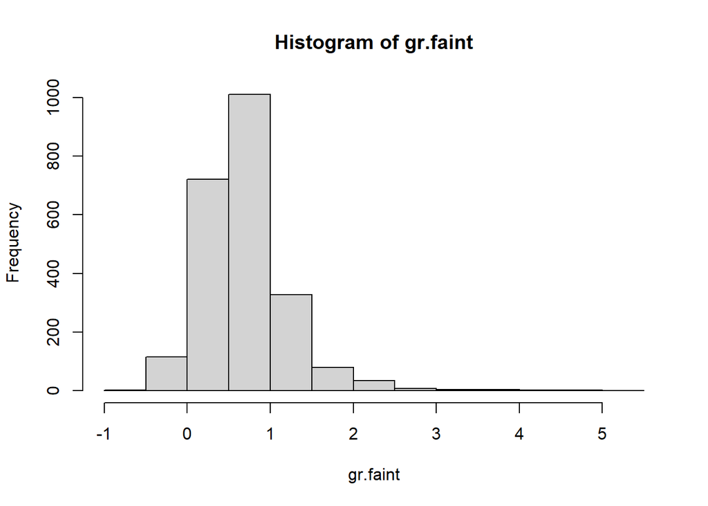

```r
# Answer to question 13
hist(gr.faint)
```

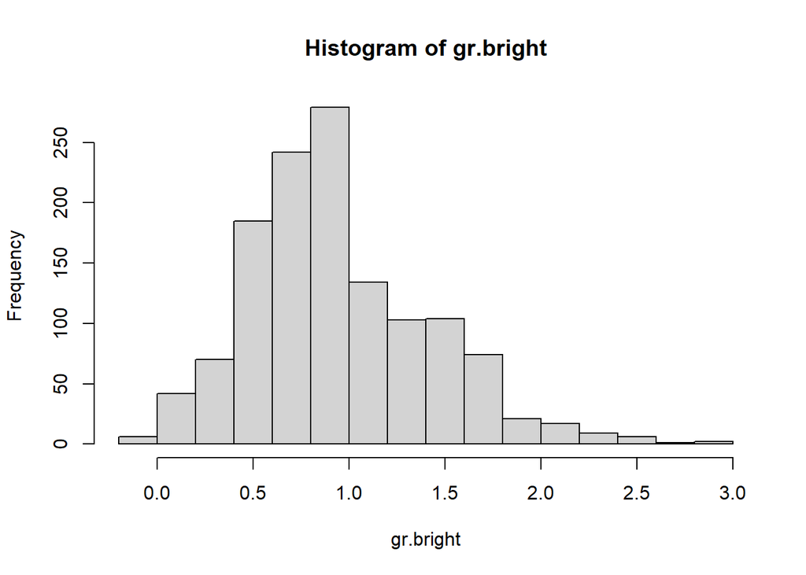

```r
hist(gr.bright)
```

```r
# a 2 sample t test is not appropriate here because this data is not normally distributed. You should really use a non parametric test (I tend to go with a wilcoxan test) to test significant differences

t.test(gr.faint, gr.bright)
```

```
##
##  Welch Two Sample t-test
##
## data:  gr.faint and gr.bright
## t = -14.389, df = 2979.8, p-value < 2.2e-16
## alternative hypothesis: true difference in means is not equal to 0
## 95 percent confidence interval:
##  -0.2816093 -0.2140635
## sample estimates:
## mean of x mean of y
## 0.6942116 0.9420480
```

```r
#If I understand correctly, this means that there is a significant difference between the average values of gr for bright and faint samples, so their means are not the same
```